# Hi there

**I’m James**, I’m a statistician currently working in healthcare analytics and modelling. Before that, I worked in digital marketing but I’m also interested in human factors research, econometrics, polling and urban design.

**You can reach me on:** Email [LinkedIn](https://www.linkedin.com/in/james-kilgour/) [GitHub](https://github.com/james-kilgour)

## Experience

### Statistician/Information Analyst

*Public Health Scotland 2024, Present*

Information Analyst/Statistician under rotating placement, currently in Excellence in Care, a team specialising in nursing/midwifery care standards. Notable past projects include:

- PCA and clustering analysis on learning disability patients (recently exhibited at the NRS Mental Health Annual Scientific Meeting).
- Forecasting hospital bed capacity using SES models.
- [Excellence in Care](https://publichealthscotland.scot/healthcare-system/system-monitoring-accountability-and-quality-of-care/excellence-in-care/overview/) dashboard development and re-design.
- See work GitHub account [here](https://github.com/jamesk-PHS).

### Senior Writer and Analyst

*CopyHouse, 2021-2024*

- Senior staff member responsible for staff training, client onboarding and strategic consultancy.
- Expanded company services to include data analysis on web traffic and search engine ranking performance.
- Client list spanned financial services and technology sectors, including brands like Facebook, Klarna, Blaylock Van, and Tractable.

### Marketing Assistant and Analyst

*Heriot-Watt University Student Union, 2018-2021*

- Introduced, and subsequently led, an annual audit of our social media audience using follower demographic and engagement data.
- Received a Bronze Award in the Marketing Society’s 2020 Star Awards for our organisational rebrand.

## Education

### MSc Applied Data Analytics

*University of the Highlands and Islands, Present*

- Studying alongside full-time employment. Data Lab Scholarship recipient. Module specialisms include statistical modelling and geospatial analysis in R.

### BSc Data Science (Applied mathematics and statistics)

*The Open University, Paused*

- Studied alongside full-time employment, achieving a 2:1 in my second year. Modules include linear algebra, calculus, statistics and python programming.

### BSc Psychology

*Heriot-Watt University, Graduated with First Class Honours*

- Awarded both the Brotherton Honours Project Prize and Best Speaker title at a British Psychological Society conference for my dissertation/presentation (respectively) on cognitive factors within political messaging campaigns.

## Skills and Software

### Statistics

- Data visualisation (ggplot2, Plotly, Excel)
- Null hypothesis testing & regression analysis
- Point/interval estimation and power analysis
- Time-series analysis and forecasting
- Multivariate analysis and clustering
- Information governance, GDPR & statistical disclosure control.

### Programming and Software

- R, tidyverse
- Markdown/Bookdown, Flexdashboard, Shiny, Excel
- SQL, HTML, CSS, Git/GitHub
- Office 365, Google Workspace
- Trello, ClickUp, Planner

### General

- Project management within agency environments
- Finance/procurement and budget optimisation
- Customer/stakeholder engagement and communication
- Line management and leadership experience

## Data viz examples

### A Sankey chart

Rankings in prevalence of long term conditions between age cohorts in Scotland. Source: [Disease Prevalence](https://publichealthscotland.scot/publications/general-practice-demographics-data-visualisation/general-practice-demographics-data-visualisation-up-to-31-december-2024/), Public Health Scotland.

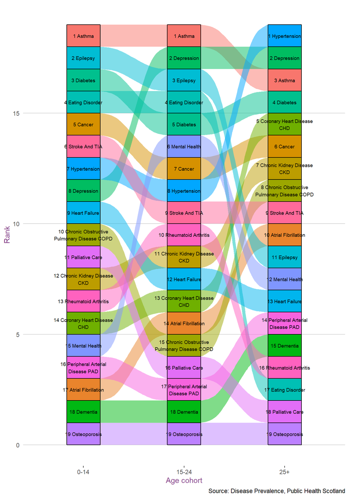

### An interactive map in `leaflet`

Use the map below to browse cycle paths in your local area. Map kindly provided Lucas Verney (Phyks on GitHub) via [CyclOSM](https://github.com/cyclosm) resource.

[interactive chart not shown]